# Superhost

Han Zhang

12/3/2021

## *logsitic regression*

*Superhost* are experienced hosts who provide a shining example for other hosts, and extraordinary experiences for their guests. Once they are called Superhosts, and their listings feature a special badge that let everyone know they are extra awesome. Althoug the airbnb websites have posted out the standards of becoming a superhost. We still want to dig out important information from the data analysis, and then provide evey host with insights about how to increase the probability of becoming a superhost.

First, we tested the correlation between covariates, and found that there existed high correlationship among same prefix variables. Since these variables contain different underlying information, we use *Principle Component Analysis* (PCA) to overcome the multicollinearity problem and extracting dominant patterns in a group of predictor.

We randomly split the observations into training set and test set at a ratio of 7:3. Since we didn’t know which varaibles should be selected, we dumped all varaibles into the regression model, and filtered out the appropriates variables according to the real situation and **Akaike information criterion** (AIC).

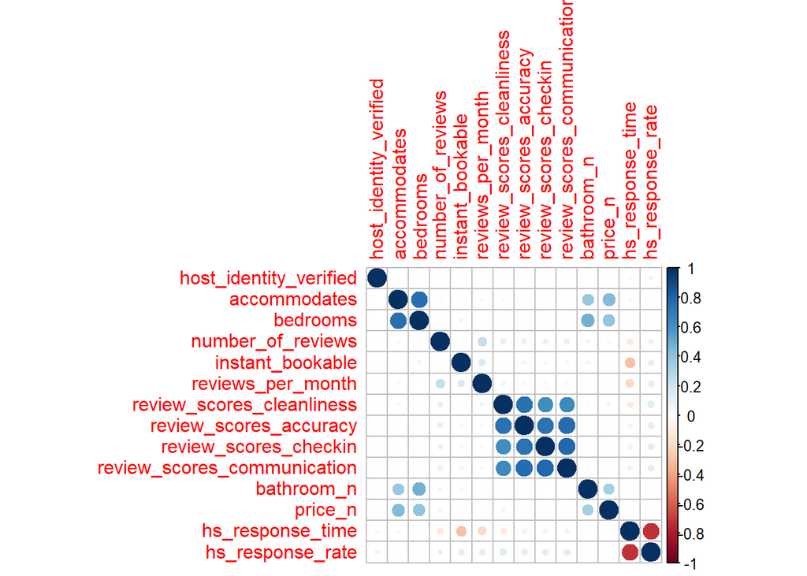

[output not shown]

[output not shown]

```
## Start:  AIC=16800.2
## hostdata4$host_is_superhost ~ host_identity_verified + accommodates +
##     bedrooms + number_of_reviews + instant_bookable + reviews_per_month +
##     review_scores_cleanliness + review_scores_accuracy + review_scores_checkin +
##     review_scores_communication + bathroom_n + price_n + hs_response_time +
##     hs_response_rate
##
##                               Df Deviance   AIC
## - price_n                      1   2713.1 16798
## - bedrooms                     1   2713.2 16798
## - accommodates                 1   2713.2 16799
## - review_scores_checkin        1   2713.3 16799
## - host_identity_verified       1   2713.4 16800
## <none>                             2713.1 16800
## - bathroom_n                   1   2713.6 16801
## - review_scores_communication  1   2714.1 16803
## - review_scores_accuracy       1   2715.2 16809
## - reviews_per_month            1   2718.6 16827
## - instant_bookable             1   2721.9 16843
## - hs_response_time             1   2728.2 16876
## - review_scores_cleanliness    1   2737.1 16922
## - hs_response_rate             1   2743.1 16953
## - number_of_reviews            1   2782.7 17154
##
## Step:  AIC=16798.21
## hostdata4$host_is_superhost ~ host_identity_verified + accommodates +
##     bedrooms + number_of_reviews + instant_bookable + reviews_per_month +
##     review_scores_cleanliness + review_scores_accuracy + review_scores_checkin +
##     review_scores_communication + bathroom_n + hs_response_time +
##     hs_response_rate
##
##                               Df Deviance   AIC
## - bedrooms                     1   2713.2 16796
## - accommodates                 1   2713.2 16797
## - review_scores_checkin        1   2713.3 16797
## - host_identity_verified       1   2713.4 16798
## <none>                             2713.1 16798
## - bathroom_n                   1   2713.7 16799
## - review_scores_communication  1   2714.1 16801
## - review_scores_accuracy       1   2715.2 16807
```

[output cut: 70 more lines]

```
##     reviews_per_month + review_scores_cleanliness + review_scores_accuracy +
##     review_scores_communication + bathroom_n + hs_response_time +
##     hs_response_rate
##
##                               Df Deviance   AIC
## <none>                             2713.7 16793
## - bathroom_n                   1   2714.2 16794
## - review_scores_communication  1   2714.5 16795
## - review_scores_accuracy       1   2715.6 16801
## - reviews_per_month            1   2719.2 16820
## - instant_bookable             1   2722.5 16837
## - hs_response_time             1   2728.7 16869
## - review_scores_cleanliness    1   2737.5 16914
## - hs_response_rate             1   2744.0 16947
## - number_of_reviews            1   2783.3 17147
```

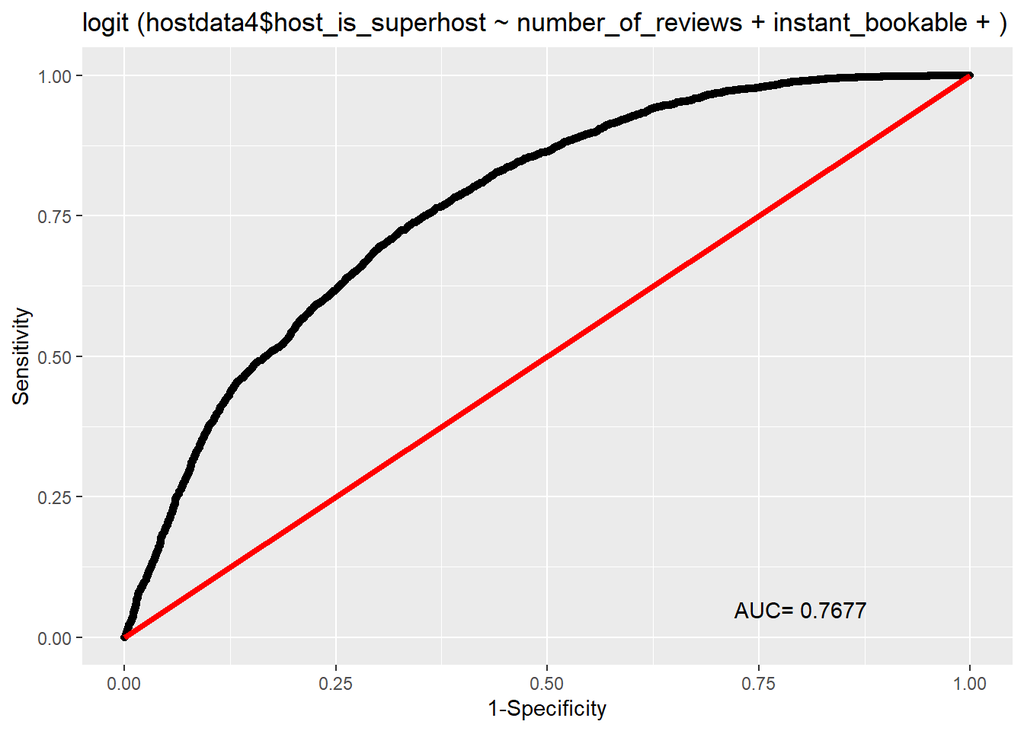

```
## Start:  AIC=16800.2
## hostdata4$host_is_superhost ~ host_identity_verified + number_of_reviews +
##     instant_bookable + reviews_per_month + Comp.1 + Comp.2 +
##     Comp.3 + Comp.4 + Comp.1.1 + Comp.2.1 + Comp.1.2 + Comp.2.2 +
##     Comp.3.1 + Comp.4.1
##
##                          Df Deviance   AIC
## - Comp.2.2                1   2713.1 16798
## - Comp.1.2                1   2713.2 16798
## - Comp.3                  1   2713.2 16798
## - Comp.4.1                1   2713.3 16799
## - host_identity_verified  1   2713.4 16800
## <none>                        2713.1 16800
## - Comp.3.1                1   2713.6 16801
## - Comp.4                  1   2713.8 16802
## - reviews_per_month       1   2718.6 16827
## - instant_bookable        1   2721.9 16843
## - Comp.2                  1   2727.6 16873
## - Comp.2.1                1   2739.1 16932
## - number_of_reviews       1   2782.7 17154
## - Comp.1                  1   2805.3 17268
## - Comp.1.1                1   2836.5 17424
##
## Step:  AIC=16798.21
## hostdata4$host_is_superhost ~ host_identity_verified + number_of_reviews +
##     instant_bookable + reviews_per_month + Comp.1 + Comp.2 +
##     Comp.3 + Comp.4 + Comp.1.1 + Comp.2.1 + Comp.1.2 + Comp.3.1 +
##     Comp.4.1
##
##                          Df Deviance   AIC
## - Comp.1.2                1   2713.2 16796
## - Comp.3                  1   2713.2 16796
## - Comp.4.1                1   2713.3 16797
## - host_identity_verified  1   2713.4 16798
## <none>                        2713.1 16798
## - Comp.3.1                1   2713.6 16799
## - Comp.4                  1   2713.8 16800
## - reviews_per_month       1   2718.6 16825
## - instant_bookable        1   2721.9 16841
## - Comp.2                  1   2727.6 16871
```

[output cut: 63 more lines]

```
## hostdata4$host_is_superhost ~ number_of_reviews + instant_bookable +
##     reviews_per_month + Comp.1 + Comp.2 + Comp.4 + Comp.1.1 +
##     Comp.2.1 + Comp.3.1
##
##                     Df Deviance   AIC
## <none>                   2713.7 16793
## - Comp.3.1           1   2714.2 16794
## - Comp.4             1   2714.3 16794
## - reviews_per_month  1   2719.2 16820
## - instant_bookable   1   2722.6 16837
## - Comp.2             1   2728.2 16866
## - Comp.2.1           1   2740.0 16927
## - number_of_reviews  1   2783.4 17148
## - Comp.1             1   2805.8 17260
## - Comp.1.1           1   2838.5 17424
```

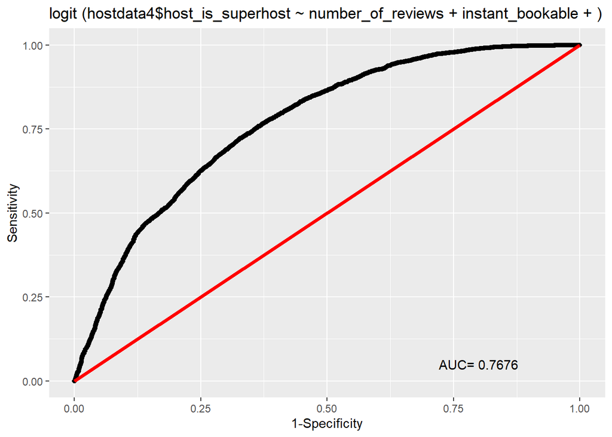

```
## Start:  AIC=16800.2
## hostdata4$host_is_superhost ~ Comp.1 + Comp.2 + Comp.3 + Comp.4 +
##     Comp.5 + Comp.6 + Comp.7 + Comp.8 + Comp.9 + Comp.10 + Comp.11 +
##     Comp.12 + Comp.13 + Comp.14
##
##           Df Deviance   AIC
## - Comp.13  1   2713.2 16799
## - Comp.12  1   2713.2 16799
## - Comp.11  1   2713.3 16799
## - Comp.2   1   2713.3 16799
## <none>         2713.1 16800
## - Comp.14  1   2713.7 16801
## - Comp.7   1   2714.5 16805
## - Comp.8   1   2715.0 16808
## - Comp.9   1   2716.0 16813
## - Comp.4   1   2722.6 16847
## - Comp.5   1   2724.9 16859
## - Comp.10  1   2726.5 16867
## - Comp.6   1   2761.7 17048
## - Comp.3   1   2844.6 17463
## - Comp.1   1   2950.5 17977
##
## Step:  AIC=16798.67
## hostdata4$host_is_superhost ~ Comp.1 + Comp.2 + Comp.3 + Comp.4 +
##     Comp.5 + Comp.6 + Comp.7 + Comp.8 + Comp.9 + Comp.10 + Comp.11 +
##     Comp.12 + Comp.14
##
##           Df Deviance   AIC
## - Comp.12  1   2713.3 16797
## - Comp.11  1   2713.4 16798
## - Comp.2   1   2713.4 16798
## <none>         2713.2 16799
## - Comp.14  1   2713.8 16800
## - Comp.7   1   2714.6 16804
## - Comp.8   1   2715.1 16806
## - Comp.9   1   2716.1 16811
## - Comp.4   1   2722.7 16846
## - Comp.5   1   2724.9 16857
## - Comp.10  1   2726.6 16866
## - Comp.6   1   2761.8 17046
```

[output cut: 42 more lines]

```
## hostdata4$host_is_superhost ~ Comp.1 + Comp.3 + Comp.4 + Comp.5 +
##     Comp.6 + Comp.7 + Comp.8 + Comp.9 + Comp.10 + Comp.14
##
##           Df Deviance   AIC
## <none>         2713.8 16795
## - Comp.14  1   2714.4 16797
## - Comp.7   1   2715.2 16801
## - Comp.8   1   2715.6 16803
## - Comp.9   1   2716.6 16808
## - Comp.4   1   2723.2 16842
## - Comp.5   1   2725.5 16854
## - Comp.10  1   2727.1 16863
## - Comp.6   1   2762.3 17043
## - Comp.3   1   2845.2 17458
## - Comp.1   1   2951.1 17972
```

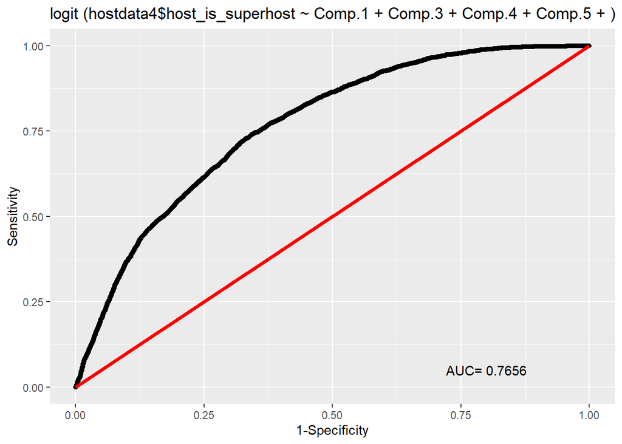

```
## Start:  AIC=11756.57
## hostdata4[-samplet, "host_is_superhost"] ~ host_identity_verified +
##     accommodates + bedrooms + number_of_reviews + instant_bookable +
##     reviews_per_month + review_scores_cleanliness + review_scores_accuracy +
##     review_scores_checkin + review_scores_communication + bathroom_n +
##     price_n + hs_response_time + hs_response_rate
##
##                               Df Deviance   AIC
## - bedrooms                     1   1896.6 11755
## - review_scores_checkin        1   1896.7 11755
## - price_n                      1   1896.7 11755
## - accommodates                 1   1896.7 11755
## <none>                             1896.6 11757
## - host_identity_verified       1   1897.0 11757
## - review_scores_communication  1   1897.5 11759
## - review_scores_accuracy       1   1897.7 11760
## - bathroom_n                   1   1897.8 11761
## - reviews_per_month            1   1899.3 11768
## - instant_bookable             1   1901.4 11779
## - hs_response_time             1   1908.8 11818
## - review_scores_cleanliness    1   1912.7 11838
## - hs_response_rate             1   1915.8 11854
## - number_of_reviews            1   1948.2 12019
##
## Step:  AIC=11754.57
## hostdata4[-samplet, "host_is_superhost"] ~ host_identity_verified +
##     accommodates + number_of_reviews + instant_bookable + reviews_per_month +
##     review_scores_cleanliness + review_scores_accuracy + review_scores_checkin +
##     review_scores_communication + bathroom_n + price_n + hs_response_time +
##     hs_response_rate
##
##                               Df Deviance   AIC
## - review_scores_checkin        1   1896.7 11753
## - price_n                      1   1896.7 11753
## - accommodates                 1   1896.7 11753
## <none>                             1896.6 11755
## - host_identity_verified       1   1897.0 11755
## - review_scores_communication  1   1897.5 11757
## - review_scores_accuracy       1   1897.7 11758
## - bathroom_n                   1   1897.9 11759
```

[output cut: 51 more lines]

```
##     review_scores_cleanliness + review_scores_accuracy + review_scores_communication +
##     bathroom_n + hs_response_time + hs_response_rate
##
##                               Df Deviance   AIC
## <none>                             1896.7 11749
## - host_identity_verified       1   1897.1 11749
## - review_scores_communication  1   1897.7 11752
## - review_scores_accuracy       1   1897.8 11753
## - bathroom_n                   1   1898.1 11754
## - reviews_per_month            1   1899.4 11761
## - instant_bookable             1   1901.5 11772
## - hs_response_time             1   1908.9 11810
## - review_scores_cleanliness    1   1912.9 11831
## - hs_response_rate             1   1916.0 11847
## - number_of_reviews            1   1948.5 12012
```

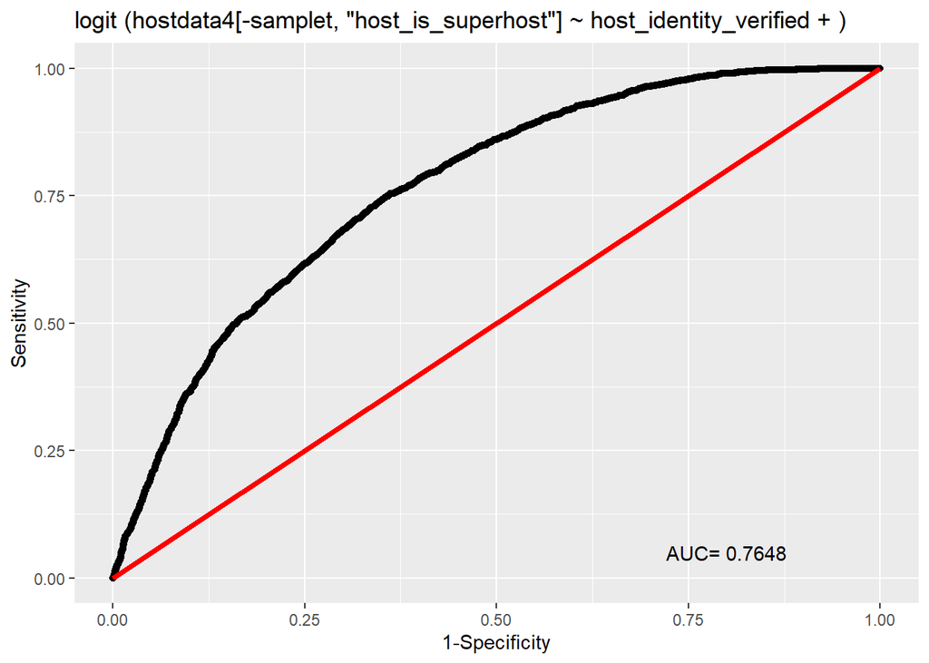

```
##
## Call:
## glm(formula = hostdata4[-samplet, "host_is_superhost"] ~ host_identity_verified +
##     number_of_reviews + instant_bookable + reviews_per_month +
##     review_scores_cleanliness + review_scores_accuracy + review_scores_communication +
##     bathroom_n + hs_response_time + hs_response_rate, data = trainhs)
##
## Deviance Residuals:
##     Min       1Q   Median       3Q      Max
## -1.4804  -0.3704  -0.2216   0.5216   1.4320
##
## Coefficients:
##                               Estimate Std. Error t value Pr(>|t|)
## (Intercept)                 -7.652e-01  6.127e-02 -12.488  < 2e-16 ***
## host_identity_verified       1.760e-02  1.235e-02   1.424 0.154389
## number_of_reviews            1.171e-03  7.147e-05  16.383  < 2e-16 ***
## instant_bookable            -5.280e-02  1.066e-02  -4.951 7.51e-07 ***
## reviews_per_month            3.378e-03  9.103e-04   3.710 0.000208 ***
## review_scores_cleanliness    1.136e-01  1.241e-02   9.152  < 2e-16 ***
## review_scores_accuracy       3.916e-02  1.637e-02   2.392 0.016778 *
## review_scores_communication  3.361e-02  1.485e-02   2.263 0.023639 *
## bathroom_n                   2.517e-02  9.316e-03   2.702 0.006900 **
## hs_response_time            -5.699e-02  7.187e-03  -7.930 2.44e-15 ***
## hs_response_rate             2.736e-01  2.737e-02   9.995  < 2e-16 ***
## ---
## Signif. codes:  0 '***' 0.001 '**' 0.01 '*' 0.05 '.' 0.1 ' ' 1
##
## (Dispersion parameter for gaussian family taken to be 0.1929535)
##
##     Null deviance: 2217.8  on 9840  degrees of freedom
## Residual deviance: 1896.7  on 9830  degrees of freedom
## AIC: 11749
##
## Number of Fisher Scoring iterations: 2
```

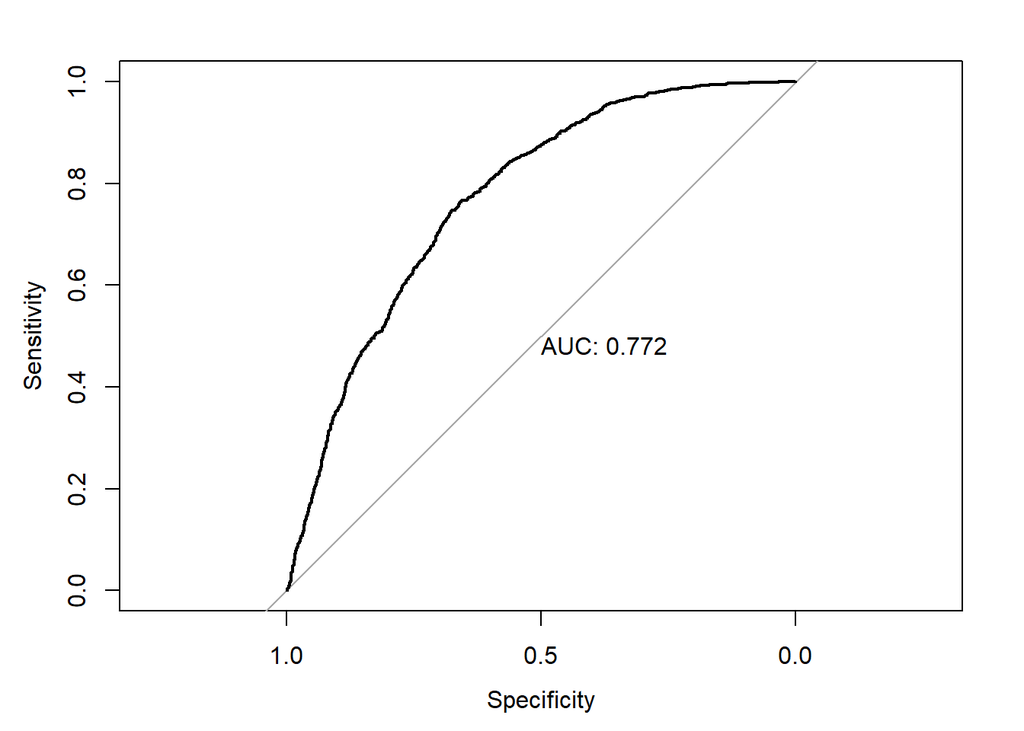

## *Associating Rule Mining*

The *ammenities* is a text variable, cantaining a list of ammenities of the house or department. We assume that there are some association between the availability of certain ammenities and the superhost. In order to dig out the information behind the sets of items, we borrow the algorithm *Association Rule* from business field. Given a set of data, we can find the rules that will predict the occurrence of superhost based on the occurrences of ammenities in the list.

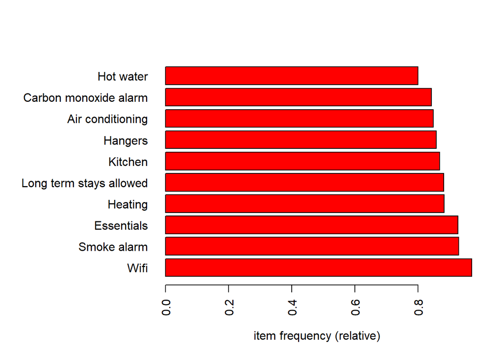

- X:$X$ is called antecedent or left-hand-side (LHS).
- Y:$Y$ is called consequent or right-hand-side (RHS)
- Support: The frequency of A in the dataset. $Supp(X) = \frac{Freq(X)}{T}$
- Confidence: How often the items X and Y occur together in the dataset when the occurence of X is already given. $Confidence = \frac{Freq(X,Y)}{Freq(X)}$
- Lift: The ratio of the observed support measure and expected support if X and Y are independent of each other. $Lift=\frac{Supp(X,Y)}{{Supp(X)}\times{Supp(X)}}$
  - $Lift=1$ : The probability of occurrence of antecedent and consequent is independent of each other.
  - $Lift>1$ : It determines the degree to which the two itemsets are dependent to each other.
  - $Lift<1$ : It tells us that one item is a substitute for other items, which means one item has a negative effect on another.

In the ammenities, there are over 1400 items. In order to find what ammenities sets appear most frequently given that the host is a superhost, we set the maximum length of rules to 10, and limit the confidence level to 0.8, and then rank the rules by lift in descending order.

Finally, we find that if the apartment has building staff and conditioner, the host is likely to be a superhost.

```r
# plotly_arules(subRules)

library(arulesViz)
association.rules <- apriori(basket2, parameter = list(supp=0.01, conf=0.8, maxlen =10),
                             appearance = list(default="lhs",rhs="superhost"))
```

```
## Apriori
##
## Parameter specification:
##  confidence minval smax arem  aval originalSupport maxtime support minlen
##         0.8    0.1    1 none FALSE            TRUE       5    0.01      1
##  maxlen target  ext
##      10  rules TRUE
##
## Algorithmic control:
##  filter tree heap memopt load sort verbose
##     0.1 TRUE TRUE  FALSE TRUE    2    TRUE
##
## Absolute minimum support count: 140
##
## set item appearances ...[1 item(s)] done [0.00s].
## set transactions ...[1445 item(s), 14059 transaction(s)] done [0.12s].
## sorting and recoding items ... [131 item(s)] done [0.01s].
## creating transaction tree ... done [0.01s].
## checking subsets of size 1 2 3 4 5
```

```
##  done [16.88s].
## writing ... [93 rule(s)] done [0.16s].
## creating S4 object  ... done [0.06s].
```

```
## To reduce overplotting, jitter is added! Use jitter = 0 to prevent jitter.
```

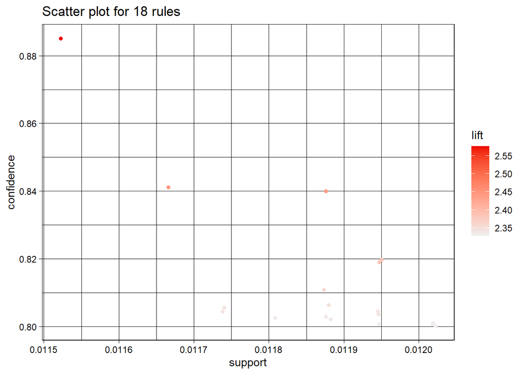

```r
subset.rules <- which(colSums(is.subset(association.rules, association.rules)) > 1)
#length(association.rules)
#length(subset.rules)
reduced_rule = association.rules[-subset.rules]
fre = sort(reduced_rule,by='lift',decreasing =T)
#inspect(fre)
plot(fre)
```

```r
#plot_arules(fre)
plot(fre, method = "graph",  engine = "htmlwidget")
```

[interactive chart not shown]

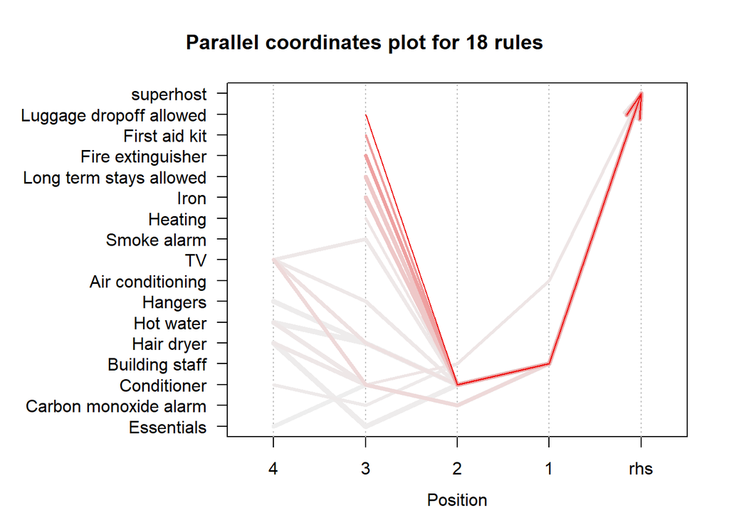

```r
plot(fre, method="paracoord")
```

```r
association.rules2 <- apriori(basket2, parameter = list(supp=0.2, conf=0.8, maxlen = 10,minlen=5),
                             appearance = list(default="lhs",rhs="non_superhost"))
```

```
## Apriori
##
## Parameter specification:
##  confidence minval smax arem  aval originalSupport maxtime support minlen
##         0.8    0.1    1 none FALSE            TRUE       5     0.2      5
##  maxlen target  ext
##      10  rules TRUE
##
## Algorithmic control:
##  filter tree heap memopt load sort verbose
##     0.1 TRUE TRUE  FALSE TRUE    2    TRUE
##
## Absolute minimum support count: 2811
##
## set item appearances ...[1 item(s)] done [0.00s].
## set transactions ...[1445 item(s), 14059 transaction(s)] done [0.12s].
## sorting and recoding items ... [41 item(s)] done [0.01s].
## creating transaction tree ... done [0.01s].
## checking subsets of size 1 2 3 4 5 6
```

```
##  done [7.13s].
## writing ... [0 rule(s)] done [0.01s].
## creating S4 object  ... done [0.01s].
```

```r
fre2 = sort(association.rules2,by='lift',decreasing =T)
#inspect(head(fre2,n=10))
```

##Comments

```r
comments = read_csv("F:/bios625/project/reviews.csv")
```